# Xia et al. Bayesian LCA - Reproduction and Extension

Giles Reid

2/5/2021

# Reproducing the Eswatini analysis

The Xia et al. (2020) paper used the `rjags` to fit a Bayesian latent class model to PHIA data from four countries. In the below we reproduce the Eswatini analysis and try out some extensions to this.

## 1. Load data for Eswatini

```r
# ?drive_auth_configure
# drive_auth_configure()
# drive_auth_config(active = FALSE)
# drive_auth(email = "jsg2145@icap.columbia.edu")

# drive_auth(email = "jsg2145@icap.columbia.edu", scopes = "https://www.googleapis.com/auth/drive.readonly")

drive_auth(scopes = "https://www.googleapis.com/auth/drive.readonly")
```

```
## Using an auto-discovered, cached token.
## To suppress this message, modify your code or options to clearly consent to the use of a cached token.
## See gargle's "Non-interactive auth" vignette for more details:
## https://gargle.r-lib.org/articles/non-interactive-auth.html
```

```
## The googledrive package is using a cached token for jsg2145@icap.columbia.edu.
```

```r
drive_user()
```

```
## Logged in as:
##   *  displayName: Jared Garfinkel
##   * emailAddress: jsg2145@icap.columbia.edu
```

```r
# x <- drive_get("~/PHIA Data Collaboration/Data/Public Release/Eswatini/Shims22016adultbio.csv")
# x <- drive_get("https://docs.google.com/spreadsheets/d/1FtvuLal09-fpY0awf759dCSoimueItKF/view?usp=sharing")
x <- as_id("https://drive.google.com/file/d/1FtvuLal09-fpY0awf759dCSoimueItKF/view?usp=sharing")
y <- as_id("https://drive.google.com/file/d/1FNfNzuQRcUWWDEnzcjYCzJjRgzKdrie2/view?usp=sharing")
# x$id
temp <- tempfile()
biodl <- drive_download(file = x, path = temp, overwrite = TRUE)
```

```
## File downloaded:
##   * Shims22016adultbio.csv
## Saved locally as:
##   * C:\Users\tempuser\AppData\Local\Temp\Rtmpsrnxvu\file9cbc1a667ae8
```

```r
temp <- tempfile()
inddl <- drive_download(file = y, path = temp, overwrite = TRUE)
```

```
## File downloaded:
##   * Shims22016adultind.csv
## Saved locally as:
##   * C:\Users\tempuser\AppData\Local\Temp\Rtmpsrnxvu\file9cbc6896552a
```

```r
# str(bio)
bio <- read_csv(biodl$local_path) %>%
  janitor::clean_names() %>%
  mutate(across(.cols = c(varstrat, varunit), .fns = as.numeric))
ind <- read_csv(inddl$local_path)
head(bio)
```

```
## # A tibble: 6 x 176
##   country householdid personid bt_status gender   age cd4count hiv1statusfinal~
##   <chr>   <chr>       <chr>        <dbl>  <dbl> <dbl> <chr>    <chr>
## 1 Eswati~ SW00000000~ SW00000~         1      1    61 .        2
## 2 Eswati~ SW00000000~ SW00000~         1      2    60 .        2
## 3 Eswati~ SW00000000~ SW00000~         1      1    32 .        2
## 4 Eswati~ SW00000000~ SW00000~         1      2    47 .        2
## 5 Eswati~ SW00000000~ SW00000~         1      2    48 .        2
## 6 Eswati~ SW00000000~ SW00000~         2      1    48 .        .
## # ... with 168 more variables: recentlagvl <dbl>, lagodnfinal <chr>,
## #   arvefv <chr>, arvlpv <chr>, arvnvp <chr>, resultvlc <chr>,
## #   surveystdt <date>, cd4cat <dbl>, hivselfreport <dbl>, hivstatusfinal <dbl>,
## #   recentlagvlarv <dbl>, aware <dbl>, art <dbl>, awareselfreported <dbl>,
## #   artselfreported <dbl>, awareartselfreported <dbl>,
## #   artinitiated12months <dbl>, artduration <dbl>, arvstatus <dbl>, vls <dbl>,
## #   tri90 <dbl>, tri90aware <dbl>, tri90art <dbl>, tri90vls <dbl>, btwt0 <chr>,
## #   varstrat <dbl>, varunit <dbl>, btwt001 <chr>, btwt002 <chr>, btwt003 <chr>,
## #   btwt004 <chr>, btwt005 <chr>, btwt006 <chr>, btwt007 <chr>, btwt008 <chr>,
## #   btwt009 <chr>, btwt010 <chr>, btwt011 <chr>, btwt012 <chr>, btwt013 <chr>,
## #   btwt014 <chr>, btwt015 <chr>, btwt016 <chr>, btwt017 <chr>, btwt018 <chr>,
## #   btwt019 <chr>, btwt020 <chr>, btwt021 <chr>, btwt022 <chr>, btwt023 <chr>,
## #   btwt024 <chr>, btwt025 <chr>, btwt026 <chr>, btwt027 <chr>, btwt028 <chr>,
## #   btwt029 <chr>, btwt030 <chr>, btwt031 <chr>, btwt032 <chr>, btwt033 <chr>,
## #   btwt034 <chr>, btwt035 <chr>, btwt036 <chr>, btwt037 <chr>, btwt038 <chr>,
## #   btwt039 <chr>, btwt040 <chr>, btwt041 <chr>, btwt042 <chr>, btwt043 <chr>,
## #   btwt044 <chr>, btwt045 <chr>, btwt046 <chr>, btwt047 <chr>, btwt048 <chr>,
## #   btwt049 <chr>, btwt050 <chr>, btwt051 <chr>, btwt052 <chr>, btwt053 <chr>,
## #   btwt054 <chr>, btwt055 <chr>, btwt056 <chr>, btwt057 <chr>, btwt058 <chr>,
## #   btwt059 <chr>, btwt060 <chr>, btwt061 <chr>, btwt062 <chr>, btwt063 <chr>,
## #   btwt064 <chr>, btwt065 <chr>, btwt066 <chr>, btwt067 <chr>, btwt068 <chr>,
## #   btwt069 <chr>, btwt070 <chr>, btwt071 <chr>, btwt072 <chr>, btwt073 <chr>,
## #   ...
```

```r
head(ind)
```

```
## # A tibble: 6 x 750
##   country householdid personid region indstatus gender   age relattohh livehere
##   <chr>   <chr>       <chr>     <dbl>     <dbl>  <dbl> <dbl>     <dbl>    <dbl>
## 1 Eswati~ SW00000000~ SW00000~      4         1      1    61         1        1
## 2 Eswati~ SW00000000~ SW00000~      4         1      2    60         2        1
## 3 Eswati~ SW00000000~ SW00000~      4         1      1    32        12        1
## 4 Eswati~ SW00000000~ SW00000~      4         1      2    47         1        1
## 5 Eswati~ SW00000000~ SW00000~      4         1      2    48         8        1
## 6 Eswati~ SW00000000~ SW00000~      1         1      1    48         1        1
## # ... with 741 more variables: sleephere <dbl>, hhrschlhl <dbl>,
## #   hhr12moaway <dbl>, emancipated <chr>, sick3mo <chr>, momalive <chr>,
## #   momhhm <chr>, femguardhhm <chr>, momfemname <chr>, dadalive <chr>,
## #   dadhhm <chr>, maleguardhhm <chr>, dadmalename <chr>, momsick <chr>,
## #   dadsick <chr>, supportmed12 <chr>, supportemot12 <chr>, supportemot3 <chr>,
## #   supportmater12 <chr>, supportmater3 <chr>, supportsocial12 <chr>,
## #   supportsocial3 <chr>, supportschol12 <chr>, lngvqx <chr>, lngvint <chr>,
## #   lngvnat <chr>, trnsluse <chr>, schlat <chr>, schlcur <chr>, schlhi <chr>,
## #   q1060lev <chr>, schcom <chr>, mont12away <chr>, mont12awaydk <chr>,
## #   mo12away <chr>, work12mo <chr>, work30days <chr>, evermar <chr>,
## #   curmar <chr>, numwif <chr>, numwifdk <chr>, reviewwife <chr>, npyn <chr>,
## #   npnum <chr>, npnumdk <chr>, npnyhstd <chr>, npnumhstd <chr>,
## #   npnumhstddk <chr>, wifliveew <chr>, wifliveewdk <chr>, huslivew <chr>,
## #   husotwif <chr>, husnwif <chr>, husnwifdk <chr>, pregnum <chr>,
## #   pregnumdk <chr>, liveb <chr>, childa2012 <chr>, childa2012dk <chr>,
## #   prgtwin <chr>, pregnm <chr>, prgcare <chr>, pregncr <chr>, hivtsbp <chr>,
## #   hivpsbp <chr>, arvfvst <chr>, hivtopg <chr>, hivtprg <chr>, hivtsnr <chr>,
## #   hivrtpg <chr>, arvtkpg <chr>, arvnrpg <chr>, brthwhr <chr>, hivtobr <chr>,
## #   hivttlb <chr>, hivrslr <chr>, offrarvs <chr>, arvtklb <chr>, arvcntn <chr>,
## #   birthyr1 <chr>, childlive1 <chr>, deathageyr1 <chr>, deathagemo1 <chr>,
## #   childlivewith1 <chr>, hhlnchild1 <chr>, childarv1 <chr>, childarvt1 <chr>,
## #   childarvdurnumw1 <chr>, childarvdurnumm1 <chr>, childbac1 <chr>,
## #   childbact1 <chr>, childscotrimdurnumw1 <chr>, childscotrimdurnumm1 <chr>,
## #   childbrstfd1 <chr>, childbrstfddur1 <chr>, childbrstfddurnum1 <chr>,
## #   birthyr2 <chr>, childlive2 <chr>, deathageyr2 <chr>, deathdkref2 <chr>, ...
```

## Select HIV+ people with non-missing values of the relevant variables

```r
eswatini.data <- ind %>%
  select(-contains("intwt"), -contains("vmpstw"), -contains("rfirs"), -starts_with("part")) %>%
  mutate(bt_status = as.numeric(bt_status)) %>%
  left_join(bio, by = c("country", "householdid", "personid", "gender", "age", "hivstatusfinal", "surveystdt", "bt_status", "varstrat", "varunit")) %>%
#
# head(eswatini.data) %>%
#   select(ends_with(".x"))
  filter(bt_status == 1 & hivstatusfinal == 1 & arvstatus %in% c(1,2) & awareselfreported %in% c(1,2))
```

## Definitions of the categories for analysis

Xia defines the following groups, for two different outcome variables, awareness of HIV+ status and ‘ever tested’ status, as follows:

| Group | True/unobserved state | ARV test result | Self-reported status |
| --- | --- | --- | --- |
| A | Truly aware/tested | ARV+ | aware/tested |
| B | Truly unaware/untested | ARV+ | aware/tested |
| C | Truly aware/tested | ARV- | aware/tested |
| D | Truly unaware/untested | ARV- | aware/tested |
| E | Truly aware/tested | ARV+ | unaware/untested |
| F | Truly unaware/untested | ARV+ | unaware/untested |
| G | Truly aware/tested | ARV- | unaware/untested |
| H | Truly unaware/untested | ARV- | unaware/untested |

The population is split into observed groups as follows:

$$y_1 = A + B \\
y_2 = C + D \\
y_3 = E + F \\
y_4 = G + H \\$$
The inputs to the model are just these four counts, $y_1 - y_4$. Coding these using our data:

```r
model.counts <- eswatini.data %>%
  mutate( y.category =
    case_when(
      arvstatus == 1 & awareselfreported == 1 ~ 1,
      arvstatus == 2 & awareselfreported == 1 ~ 2,
      arvstatus == 1 & awareselfreported == 2 ~ 3,
      arvstatus == 2 & awareselfreported == 2 ~ 4,
      TRUE ~ 99
    )
  ) %>%
  filter( y.category != 99 ) %>%
  select( personid, y.category, age, gender, awareselfreported, arvstatus, hivstatusfinal ) %>%
  group_by(awareselfreported, arvstatus, y.category) %>%
  summarise(count = n())
model.counts
```

```
## # A tibble: 4 x 4
## # Groups:   awareselfreported, arvstatus [4]
##   awareselfreported arvstatus y.category count
##               <dbl>     <dbl>      <dbl> <int>
## 1                 1         1          1  2219
## 2                 1         2          2   374
## 3                 2         1          3    59
## 4                 2         2          4   345
```

To recap, these $y$s count the following groups of PLHIV:

- $y_1$: ARV+ and self-reported aware,
- $y_2$: ARV- and self-reported aware,
- $y_3$: ARV+ and self-reported unaware,
- $y_4$: ARV- and self-reported unaware.

## Setting up the model

The `rjags` package connects to the JAGS (“Just Another Gibbs Sampler”) package, which runs outside of R and needs to be installed separately. To use it, we have to have a model definition. For the model in Xia et al.’s paper, I started from the equations in the supplemental materials, and translated these into the BUGS language. These equations define how to calculate the likelihood for the model, given a set of parameter values. They need to be written in such a way that they can be tracked back to a constant or a sample-able probability distribution, so that the Gibbs sampler/MCMC algorithm can proceed through its update/accept cycle. The full encoded model looks like this:

```
model {

  p[1] = pi * sesrpos * covarv             + (1 - pi) * (1 - spsr) * (1 - sparv)
  p[2] = pi * sesrneg * (1 - covarv)       + (1 - pi) * (1 - spsr) * sparv
  p[3] = pi * (1 - sesrpos) * covarv       + (1 - pi) * spsr * (1 - sparv)
  p[4] = pi * (1 - sesrneg) * (1 - covarv) + (1 - pi) * spsr * sparv
  sesrneg = 1 - ratio * (1 - sesrpos)

  y[1:4] ~ dmulti(p[1:4], N)
  pi ~ dunif(0, 1)
  sesrpos ~ dunif(0, 1)
  spsr = 1

  covarv ~ dunif(0, 1)
  sparv = 1
  R ~ dnorm( 0.3920421, 4.0)
  ratio = exp( R )

}
```

This is saved in an external text file and becomes an input to the `jags.model` function. I’ve also put in some initial values, this is maybe not strictly necessary but helps give a more robust result.

### Explanation of the model code

The variables are as follows:

[output not shown]

So there’s no restriction or prior on the sensitivities or the proportions with ARVs or truly aware. The `ratio` parameter is probably the most interesting one - it’s set here based on other studies showing that people are less likely/more reluctant to say they know they’re HIV+ when they aren’t on treatment. The distribution here looks like this:

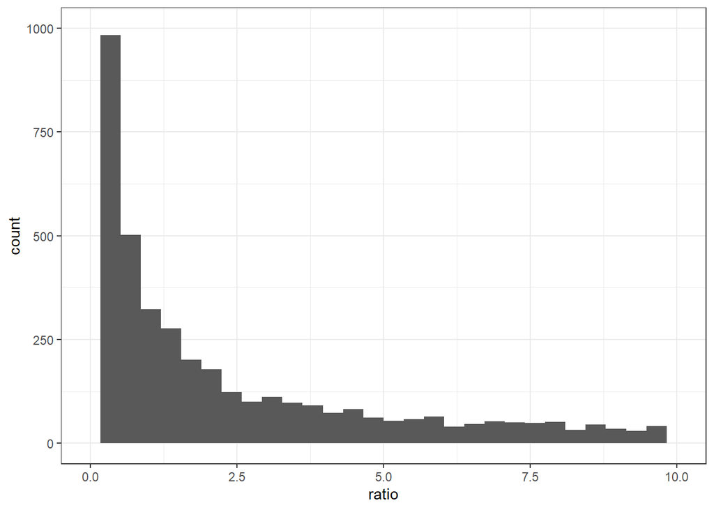

```r
ratio_vals <- as_tibble_col( exp( rnorm(10000, mean = log(1.48), 4.0)), "ratio" )
ggplot(ratio_vals, aes(x = ratio)) +
  geom_histogram() +
  scale_x_continuous(limits = c(0, 10)) +
  scale_y_continuous(limits = c(0, 1000)) + theme_bw()
```

## Running the model

`jags.model` creates the model object ready to be sampled from, `update` runs through a specified number of iterations for burn-in, and `coda.samples` does the final sampling from the model runs, saving values of the variables specified into an output file for analysis.

```r
model.data <- list( "y" = model.counts$count, "N" = sum(model.counts$count))

initial.values <- list(
                        list( pi = 0.8, R = 0.0, covarv = .6),
                        list( pi = 0.6, R = 0.4, covarv = .8),
                        list( pi = 0.9, R = 0.3, covarv = .7),
                        list( pi = 0.3, R = 0.1, covarv = .2)
                      )

model <- jags.model("./data/xiamodel.txt", data = model.data, n.chains = 4)
update(model, n.iter=1000)
samples <- coda.samples(model, variable.names=c("pi", "ratio", "sesrpos", "sesrneg", "covarv", "p"),
                        n.iter=1000)

summary(samples)
```

```
##
## Iterations = 2001:3000
## Thinning interval = 1
## Number of chains = 4
## Sample size per chain = 1000
##
## 1. Empirical mean and standard deviation for each variable,
##    plus standard error of the mean:
##
##            Mean       SD  Naive SE Time-series SE
## covarv  0.85306 0.007581 1.199e-04      1.716e-04
## p[1]    0.73978 0.008009 1.266e-04      1.588e-04
## p[2]    0.12506 0.006030 9.534e-05      1.197e-04
## p[3]    0.01995 0.002557 4.043e-05      5.287e-05
## p[4]    0.11521 0.005785 9.147e-05      1.143e-04
## pi      0.89061 0.006690 1.058e-04      1.666e-04
## ratio   1.67450 0.837318 1.324e-02      2.439e-02
## sesrneg 0.95612 0.022546 3.565e-04      6.727e-04
## sesrpos 0.97374 0.003353 5.301e-05      6.765e-05
##
## 2. Quantiles for each variable:
##
##            2.5%    25%     50%     75%   97.5%
## covarv  0.83825 0.8479 0.85326 0.85845 0.86702
## p[1]    0.72404 0.7342 0.73977 0.74513 0.75544
## p[2]    0.11390 0.1208 0.12508 0.12915 0.13717
## p[3]    0.01528 0.0182 0.01984 0.02159 0.02529
## p[4]    0.10399 0.1113 0.11512 0.11902 0.12683
## pi      0.87768 0.8862 0.89054 0.89485 0.90426
## ratio   0.56223 1.0795 1.50345 2.07136 3.75127
## sesrneg 0.90120 0.9454 0.96083 0.97237 0.98582
## sesrpos 0.96671 0.9716 0.97388 0.97604 0.97985
```

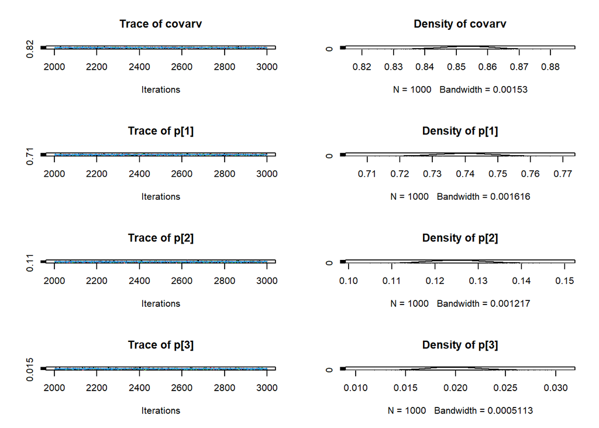

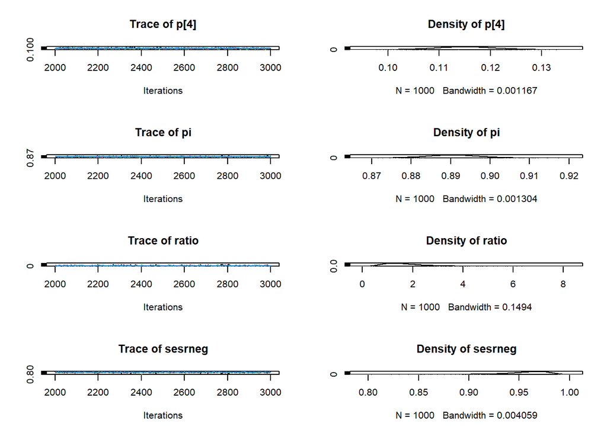

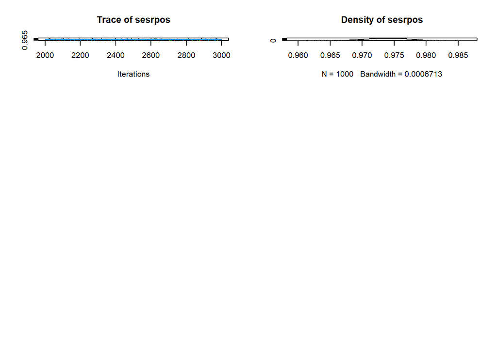

```r
plot(samples)
```

```r
(fitted.stats <- bind_cols(var = rownames(summary(samples)$statistics), as_tibble(summary(samples)$statistics)))
```

```
## # A tibble: 9 x 5
##   var       Mean      SD `Naive SE` `Time-series SE`
##   <chr>    <dbl>   <dbl>      <dbl>            <dbl>
## 1 covarv  0.853  0.00758  0.000120         0.000172
## 2 p[1]    0.740  0.00801  0.000127         0.000159
## 3 p[2]    0.125  0.00603  0.0000953        0.000120
## 4 p[3]    0.0200 0.00256  0.0000404        0.0000529
## 5 p[4]    0.115  0.00579  0.0000915        0.000114
## 6 pi      0.891  0.00669  0.000106         0.000167
## 7 ratio   1.67   0.837    0.0132           0.0244
## 8 sesrneg 0.956  0.0225   0.000356         0.000673
## 9 sesrpos 0.974  0.00335  0.0000530        0.0000676
```

```r
(fitted.quantiles <- bind_cols(var = rownames(summary(samples)$statistics), as_tibble(summary(samples)$quantiles)))
```

```
## # A tibble: 9 x 6
##   var     `2.5%`  `25%`  `50%`  `75%` `97.5%`
##   <chr>    <dbl>  <dbl>  <dbl>  <dbl>   <dbl>
## 1 covarv  0.838  0.848  0.853  0.858   0.867
## 2 p[1]    0.724  0.734  0.740  0.745   0.755
## 3 p[2]    0.114  0.121  0.125  0.129   0.137
## 4 p[3]    0.0153 0.0182 0.0198 0.0216  0.0253
## 5 p[4]    0.104  0.111  0.115  0.119   0.127
## 6 pi      0.878  0.886  0.891  0.895   0.904
## 7 ratio   0.562  1.08   1.50   2.07    3.75
## 8 sesrneg 0.901  0.945  0.961  0.972   0.986
## 9 sesrpos 0.967  0.972  0.974  0.976   0.980
```

These calculations all come out the same as what’s reported in the Xia paper for Eswatini, so we seem to have set up the model correctly. You can see some of the standard model fitting plots here too - I’ve suppressed these for the rest of the document for brevity.

There’s also another package called `run.jags` which can be used - it has some other options and outputs but the basic results should be the same.

```r
monitors <- c("pi", "ratio", "sesrpos", "sesrneg", "covarv")

out <- run.jags(model="./data/xiamodel.txt", monitor=monitors,
                 data=model.data, n.chains=4, method="parallel", inits=initial.values)
```

[output not shown]

```r
print(out)
```

```
##
## JAGS model summary statistics from 40000 samples (chains = 4; adapt+burnin = 5000):
##
##         Lower95  Median Upper95    Mean        SD Mode       MCerr MC%ofSD
## pi      0.87698 0.89046 0.90404 0.89065 0.0070066   -- 0.000066467     0.9
## ratio   0.37413  1.5024  3.5032  1.7024   0.93016   --   0.0099522     1.1
## sesrpos 0.96691 0.97377 0.98009 0.97362 0.0033842   -- 0.000022416     0.7
## sesrneg 0.90626 0.96074 0.99019 0.95509  0.025513   --  0.00027886     1.1
## covarv  0.83779 0.85334 0.86792 0.85303 0.0077997   -- 0.000067842     0.9
##
##         SSeff      AC.10   psrf
## pi      11112   0.027475 1.0007
## ratio    8735   0.032698 1.0001
## sesrpos 22792 -0.0013191 1.0002
## sesrneg  8370   0.040742 1.0002
## covarv  13218   0.014632 1.0001
##
## Total time taken: 11.9 seconds
```

```r
summary(out)
```

```
##          Lower95    Median  Upper95      Mean          SD Mode        MCerr
## pi      0.876979 0.8904610 0.904035 0.8906506 0.007006643   NA 6.646710e-05
## ratio   0.374130 1.5024150 3.503190 1.7023806 0.930157804   NA 9.952158e-03
## sesrpos 0.966915 0.9737730 0.980090 0.9736221 0.003384187   NA 2.241645e-05
## sesrneg 0.906261 0.9607370 0.990188 0.9550921 0.025512598   NA 2.788637e-04
## covarv  0.837795 0.8533385 0.867917 0.8530336 0.007799735   NA 6.784159e-05
##         MC%ofSD SSeff        AC.10     psrf
## pi          0.9 11112  0.027475073 1.000701
## ratio       1.1  8735  0.032698232 1.000108
## sesrpos     0.7 22792 -0.001319132 1.000215
## sesrneg     1.1  8370  0.040742437 1.000176
## covarv      0.9 13218  0.014631711 1.000125
```

```r
#plot(out)

fitted.values <- bind_cols(var = monitors, as_tibble(summary(out)))
```

## What if we use viral load less than 200 instead of ARV status?

Because the model explicitly computes an estimate (`pi`) of the true awareness among the PLHIV population, we can use this same model to compute an adjusted prevalence using other variables. For example, here’s what happens if we use viral load less than 200 copies/mL instead of the ARV status. Note here that the assumption of perfect specificity of ARVs, which seems very reasonable in that case (ie. nobody is going to have detected ARVs who isn’t truly aware and on ARVs), is perhaps not quite as robust due to the possible existence of people who are ‘elite controllers’ (virally suppressed without ARVs).

```r
model.counts.vl <- eswatini.data %>%
  mutate(  resultvln = as.numeric(resultvlc),
           vl_lt_200 = case_when(
                        grepl("<", resultvlc, fixed = TRUE) ~ 1,
                        resultvln >= 0 & resultvln < 200 ~ 1,
                        resultvln >= 200 ~ 2,
                        TRUE ~ 99),
            y.category =
            case_when(
              vl_lt_200 == 1 & awareselfreported == 1 ~ 1,
              vl_lt_200 == 2 & awareselfreported == 1 ~ 2,
              vl_lt_200 == 1 & awareselfreported == 2 ~ 3,
              vl_lt_200 == 2 & awareselfreported == 2 ~ 4,
              TRUE ~ 99
            )
  ) %>%
  filter( y.category != 99 ) %>%
  select( personid, y.category, age, gender, awareselfreported, arvstatus, vl_lt_200, hivstatusfinal ) %>%
  group_by(awareselfreported, vl_lt_200, y.category) %>%
  summarise(count = n())
model.counts.vl
```

```
## # A tibble: 4 x 4
## # Groups:   awareselfreported, vl_lt_200 [4]
##   awareselfreported vl_lt_200 y.category count
##               <dbl>     <dbl>      <dbl> <int>
## 1                 1         1          1  2063
## 2                 1         2          2   530
## 3                 2         1          3    62
## 4                 2         2          4   342
```

```r
model.data.vl <- list( "y" = model.counts.vl$count, "N" = sum(model.counts.vl$count))

initial.values <- list(
  list( pi = 0.8, R = 0.0, covarv = .6),
  list( pi = 0.6, R = 0.4, covarv = .8)
)

model.vl <- jags.model("./data/xiamodel.txt", data = model.data.vl, n.chains = 2)
```

```r
update(model.vl, n.iter=1000)
samples.vl <- coda.samples(model.vl, variable.names=c("pi", "ratio", "sesrpos", "sesrneg", "covarv", "p"),
                        n.iter=1000)

#plot(samples.vl)
```

Let’s compare the results using the viral load variable to ARV status:

```r
summary(samples.vl)
```

```
##
## Iterations = 2001:3000
## Thinning interval = 1
## Number of chains = 2
## Sample size per chain = 1000
##
## 1. Empirical mean and standard deviation for each variable,
##    plus standard error of the mean:
##
##            Mean       SD  Naive SE Time-series SE
## covarv  0.79155 0.009755 2.181e-04      4.556e-04
## p[1]    0.68782 0.008634 1.931e-04      2.441e-04
## p[2]    0.17685 0.007119 1.592e-04      2.156e-04
## p[3]    0.02104 0.002592 5.796e-05      8.615e-05
## p[4]    0.11430 0.005922 1.324e-04      1.517e-04
## pi      0.89557 0.008524 1.906e-04      4.665e-04
## ratio   1.75436 0.965761 2.160e-02      6.130e-02
## sesrneg 0.94808 0.028936 6.470e-04      1.853e-03
## sesrpos 0.97033 0.003626 8.108e-05      1.201e-04
##
## 2. Quantiles for each variable:
##
##            2.5%     25%     50%     75%   97.5%
## covarv  0.77057 0.78589 0.79203 0.79819 0.80868
## p[1]    0.67027 0.68235 0.68777 0.69391 0.70440
## p[2]    0.16352 0.17215 0.17657 0.18151 0.19139
## p[3]    0.01627 0.01916 0.02102 0.02281 0.02631
## p[4]    0.10297 0.11012 0.11420 0.11823 0.12605
## pi      0.88067 0.89003 0.89494 0.90035 0.91513
## ratio   0.54507 1.08700 1.55465 2.14537 4.22620
## sesrneg 0.87425 0.93584 0.95472 0.96796 0.98453
## sesrpos 0.96299 0.96779 0.97038 0.97300 0.97700
```

```r
summary(samples)
```

```
##
## Iterations = 2001:3000
## Thinning interval = 1
## Number of chains = 4
## Sample size per chain = 1000
##
## 1. Empirical mean and standard deviation for each variable,
##    plus standard error of the mean:
##
##            Mean       SD  Naive SE Time-series SE
## covarv  0.85306 0.007581 1.199e-04      1.716e-04
## p[1]    0.73978 0.008009 1.266e-04      1.588e-04
## p[2]    0.12506 0.006030 9.534e-05      1.197e-04
## p[3]    0.01995 0.002557 4.043e-05      5.287e-05
## p[4]    0.11521 0.005785 9.147e-05      1.143e-04
## pi      0.89061 0.006690 1.058e-04      1.666e-04
## ratio   1.67450 0.837318 1.324e-02      2.439e-02
## sesrneg 0.95612 0.022546 3.565e-04      6.727e-04
## sesrpos 0.97374 0.003353 5.301e-05      6.765e-05
##
## 2. Quantiles for each variable:
##
##            2.5%    25%     50%     75%   97.5%
## covarv  0.83825 0.8479 0.85326 0.85845 0.86702
## p[1]    0.72404 0.7342 0.73977 0.74513 0.75544
## p[2]    0.11390 0.1208 0.12508 0.12915 0.13717
## p[3]    0.01528 0.0182 0.01984 0.02159 0.02529
## p[4]    0.10399 0.1113 0.11512 0.11902 0.12683
## pi      0.87768 0.8862 0.89054 0.89485 0.90426
## ratio   0.56223 1.0795 1.50345 2.07136 3.75127
## sesrneg 0.90120 0.9454 0.96083 0.97237 0.98582
## sesrpos 0.96671 0.9716 0.97388 0.97604 0.97985
```

## Multi-country analysis

I ran similar analysis across all the PHIA countries (except Zambia because the dataset was not loading properly). Here’s some graphs of the main results.

```r
library(pals)
library(RColorBrewer)
library(colorRamps)

z = as_id("https://drive.google.com/file/d/1bZ0-ShZ8535-3d7GvOYkiMLllbb5e58S/view?usp=sharing")

multicountry.datadl <- drive_download(file = z, path = temp, overwrite = TRUE)
```

```
## Auto-refreshing stale OAuth token.
```

```
## File downloaded:
##   * multicountry_model_out_2.xlsx
## Saved locally as:
##   * C:\Users\tempuser\AppData\Local\Temp\Rtmpsrnxvu\file9cbc6896552a
```

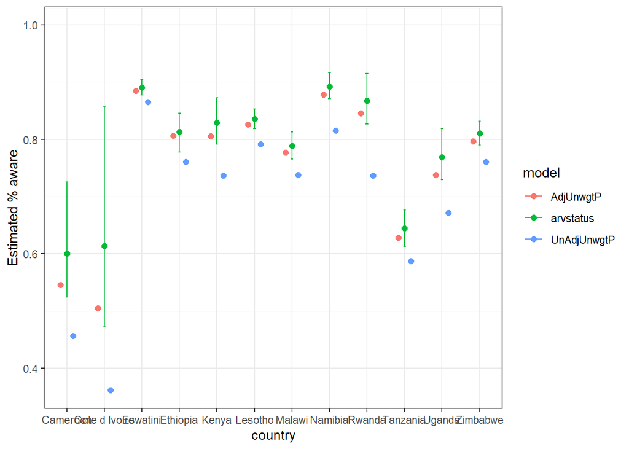

```r
# str(multicountry.datadl)

multicountry.data = readxl::read_xlsx(multicountry.datadl$local_path)
#awareness <-
  #filter(var == "covarv")
  #filter(var == "ratio")
  #filter(var == "sesrpos")
  #filter(var == "sesrneg")

pd <- position_dodge(width = 0.5)

multicountry.data %>%
  filter(var == "pi" & !(model %in% c("AdjWgtP", "UnAdjWgtP", "vl_lt_200")) ) %>%
  ggplot(aes(x = country, y = Mean, colour = model, group = model)) +
  geom_point(position = pd, size = 2) +
  geom_errorbar(aes(ymin = Lower95, ymax = Upper95), width = 0.2, position = pd) +
  expand_limits(y = c(0.5, 1)) +
  theme_bw() +
  ylab("Estimated % aware")
```

We can also compare the adjusted awareness from using the arvstatus PHIA recode to the model using arvstatus and the model using viral load < 200 copies/mL (`vl_lt_200`).

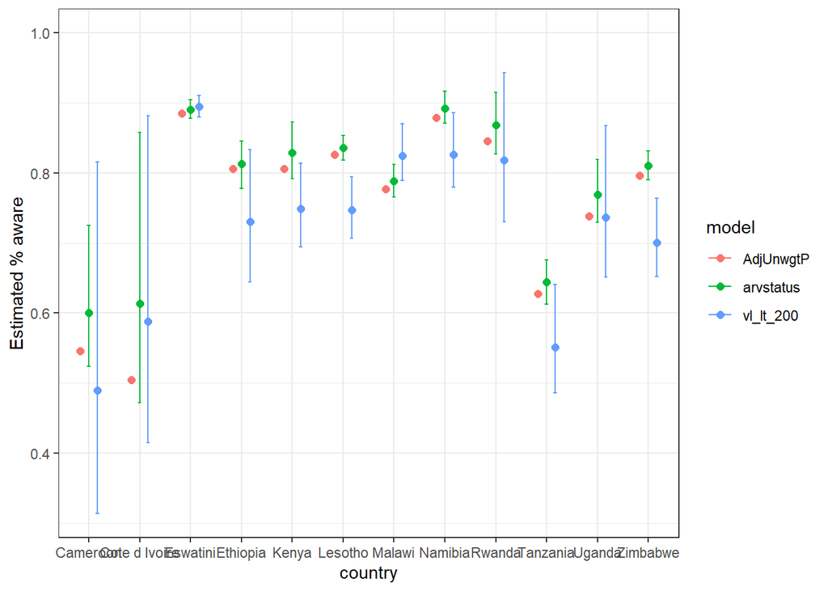

```r
multicountry.data %>%
  filter(var == "pi" & (model %in% c("AdjUnwgtP", "arvstatus", "vl_lt_200")) ) %>%
  ggplot(aes(x = country, y = Mean, colour = model, group = model)) +
  geom_point(position = pd, size = 2) +
  geom_errorbar(aes(ymin = Lower95, ymax = Upper95), width = 0.2, position = pd) +
  expand_limits(y = c(0.5, 1)) +
  theme_bw() +
  ylab("Estimated % aware")
```

In some countries the estimate is much lower using the viral load. What’s going on here? We can examine the estimates for the proportion of self-reported aware and self-reported unawares who have viral load under 200, as well as the sensitivity estimates in each model:

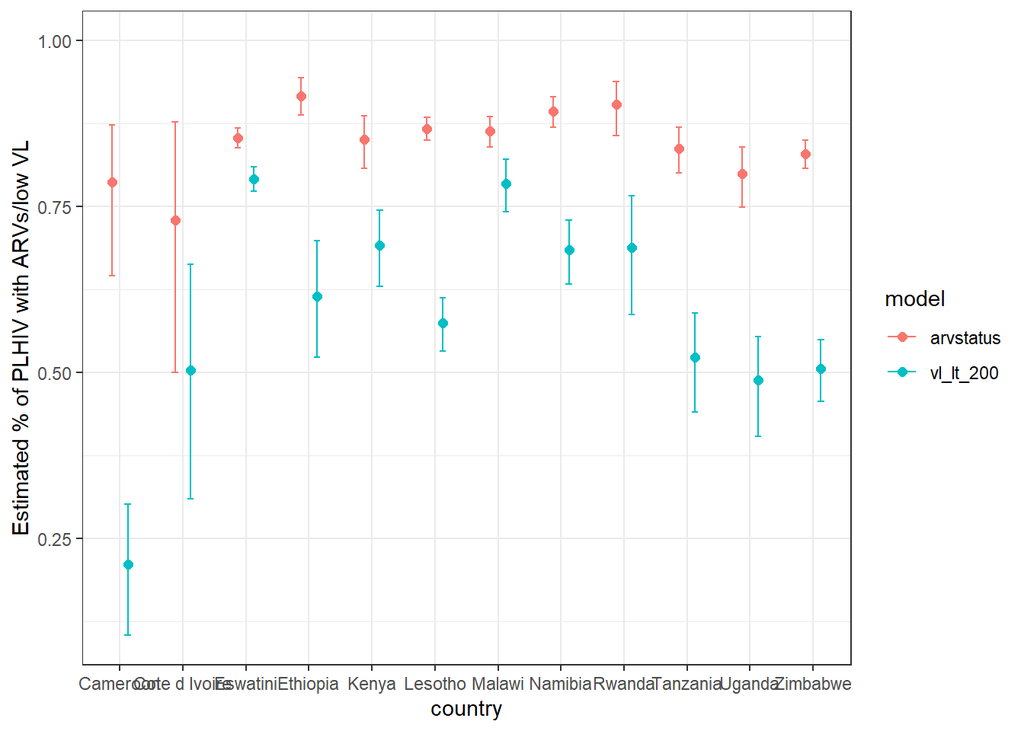

```r
multicountry.data %>%
  filter(var == "covarv" & (model %in% c("arvstatus", "vl_lt_200")) ) %>%
  ggplot(aes(x = country, y = Mean, colour = model, group = model)) +
  geom_point(position = pd, size = 2) +
  geom_errorbar(aes(ymin = Lower95, ymax = Upper95), width = 0.2, position = pd) +
  expand_limits(y = c(0.5, 1)) +
  theme_bw() +
  ylab("Estimated % of PLHIV with ARVs/low VL")
```

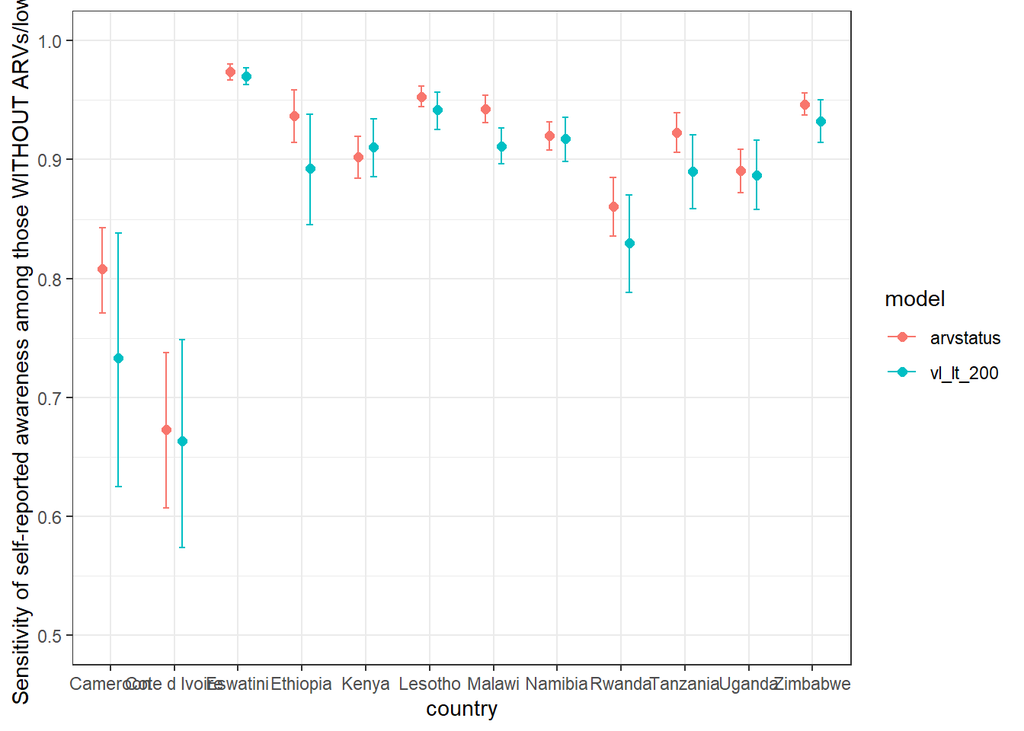

```r
multicountry.data %>%
  filter(var == "sesrpos" & (model %in% c("arvstatus", "vl_lt_200")) ) %>%
  ggplot(aes(x = country, y = Mean, colour = model, group = model)) +
  geom_point(position = pd, size = 2) +
  geom_errorbar(aes(ymin = Lower95, ymax = Upper95), width = 0.2, position = pd) +
  expand_limits(y = c(0.5, 1)) +
  theme_bw() +
  ylab("Sensitivity of self-reported awareness among those WITHOUT ARVs/low vl")
```

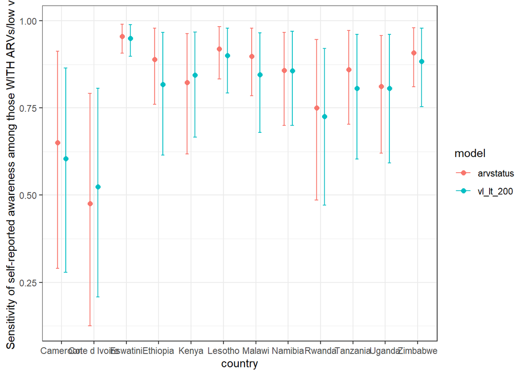

```r
multicountry.data %>%
  filter(var == "sesrneg" & (model %in% c("arvstatus", "vl_lt_200")) ) %>%
  ggplot(aes(x = country, y = Mean, colour = model, group = model)) +
  geom_point(position = pd, size = 2) +
  geom_errorbar(aes(ymin = Lower95, ymax = Upper95), width = 0.2, position = pd) +
  expand_limits(y = c(0.5, 1)) +
  theme_bw() +
  ylab("Sensitivity of self-reported awareness among those WITH ARVs/low vl")
```

Also we can look at the probabilities to be in each class:

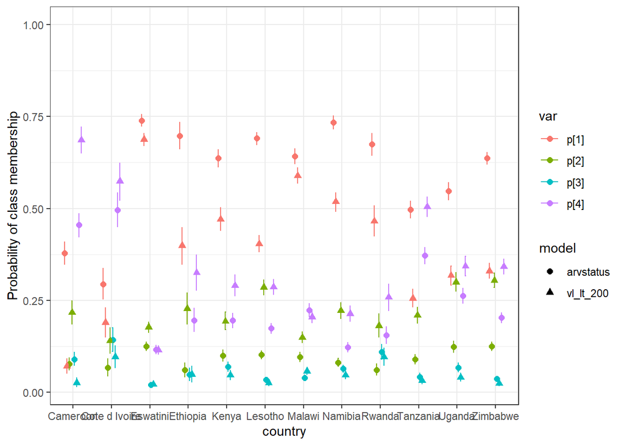

```r
multicountry.data %>%
  filter(grepl("p[", var, fixed = TRUE) & (model %in% c("arvstatus", "vl_lt_200")) ) %>%
  ggplot(aes(x = country, y = Mean, colour = var, shape = model)) +
  geom_point(position = pd, size = 2) +
  geom_errorbar(aes(ymin = Lower95, ymax = Upper95), width = 0.2, position = pd) +
  expand_limits(y = c(0.5, 1)) +
  theme_bw() +
  ylab("Probability of class membership")
```

In at least a few countries, $p_4$ is a lot higher than $p_1$ for the `vl_lt_200` model. Class one is the self-reported aware people with ARVs/low vl detected, and class four is the self-report unaware with ARVs/low vl not detected.

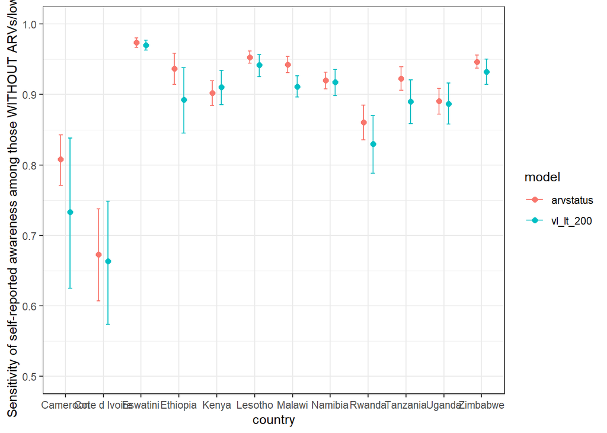

```r
multicountry.data %>%
  filter(var == "sesrpos" & (model %in% c("arvstatus", "vl_lt_200")) ) %>%
  ggplot(aes(x = country, y = Mean, colour = model, group = model)) +
  geom_point(position = pd, size = 2) +
  geom_errorbar(aes(ymin = Lower95, ymax = Upper95), width = 0.2, position = pd) +
  expand_limits(y = c(0.5, 1)) +
  theme_bw() +
  ylab("Sensitivity of self-reported awareness among those WITHOUT ARVs/low vl")
```

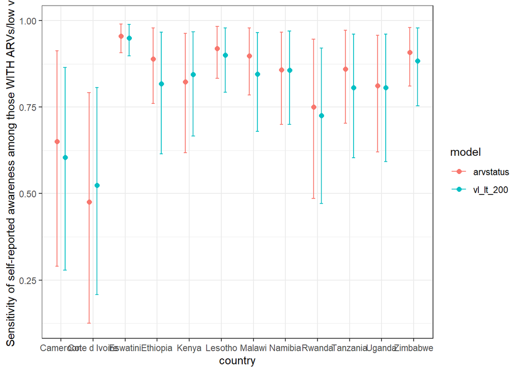

```r
multicountry.data %>%
  filter(var == "sesrneg" & (model %in% c("arvstatus", "vl_lt_200")) ) %>%
  ggplot(aes(x = country, y = Mean, colour = model, group = model)) +
  geom_point(position = pd, size = 2) +
  geom_errorbar(aes(ymin = Lower95, ymax = Upper95), width = 0.2, position = pd) +
  expand_limits(y = c(0.5, 1)) +
  theme_bw() +
  ylab("Sensitivity of self-reported awareness among those WITH ARVs/low vl")
```

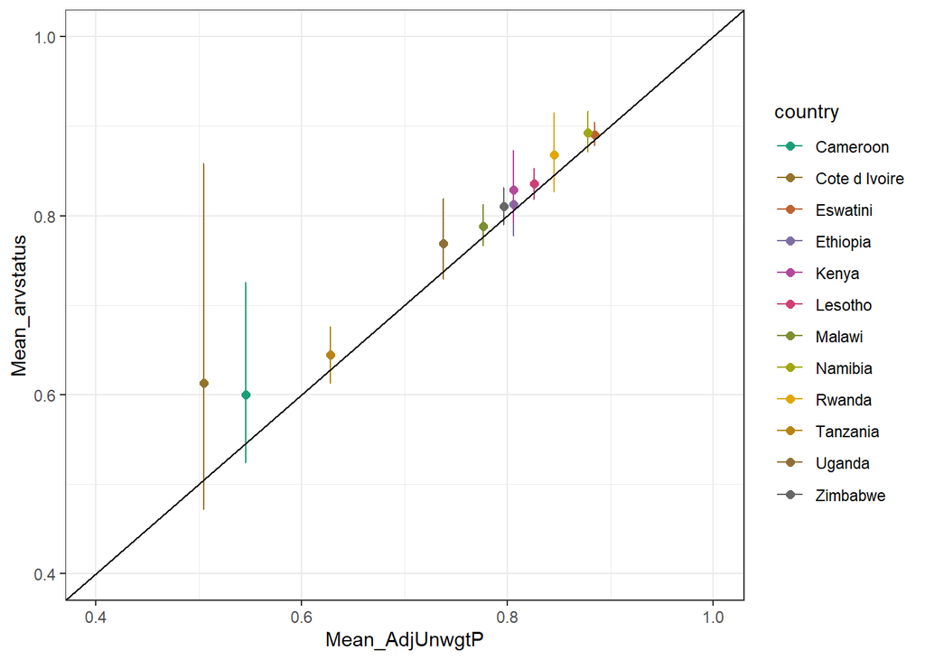

```r
# Plot to show the magnitude of adjustments
aware_adj_plot <- multicountry.data %>%
  select(country, var, Mean, model, Lower95, Upper95) %>%
  pivot_wider(id_cols = c(country, var), names_from = model, values_from = c(Mean, Lower95, Upper95)) %>%
  filter(var == "pi")


ggplot(data = aware_adj_plot, aes(x = Mean_AdjUnwgtP, y = Mean_arvstatus, colour = country, group = country)) +
  geom_point(size = 2) +
  geom_errorbar(aes(ymin = Lower95_arvstatus, ymax = Upper95_arvstatus)) +
  geom_abline(slope = 1, intercept = 0) +
  expand_limits(y = c(0.4, 1), x = c(0.4, 1)) +
  theme_bw() +
  scale_colour_manual(values = colorRampPalette(brewer.pal(8, "Dark2"))(12))
```